# Chapter 5: Time Value of Money

FINA 3000 · Business Finance I · Class 4

Dr. Justin Mohr

September 3, 2026

## Choices

- $100 today or $100 a year from now?
- $100 today or $105 a year from now?
- $100 today or $110 a year from now?

## Time is money

Why do we want money sooner?

- Then we can do productive things with it!
- Invest it and have it generate interest
- Today we are going to talk about the mathematical fundamentals of the time value of money
  - FV, PV and annuities
- I aim to foster an environment where y’all feel comfortable asking questions.
  - Today, especially, I want to encourage to ask questions!
  - This material underpins the rest of the course.

## Discount Rate

- I offer you $100 dollars today or $105 dollars a year from today.
- If I give you the money today, you could invest it and it would return 6% over the next year.

Which would you choose? Why?

100 dollars today!!

$$\$100*\left(1+6\%\right)=\$106>\$105$$

- Here 6% is our discount rate
  - What would I do with the money if I had it today?
  - Do you trust me?
    - Default Risk Premium

## There 6% was our discount rate.

What does a discount rate reflect?

- Opportunity cost: Money today can be invested and earn interest.
- Inflation: Money looses value over time.
- Uncertainty: Something could happen? What if you don’t trust me?

## FV

- Future value is what a CF or series of cash flows will be worth in the future

Think back to my offer, what is the FV of $100 a year from today grown at 6%?

$$\$100*\left(1+6\%\right)=\$106!!$$

What would it be if you grew it for 2 years at 6%?

$$\begin{array}{rlll}
FV_{1}=106\rightarrow FV_{2} = & \$106*\left(1+6\%\right) & = & 112.36 \\
\text{or} & & & \\
FV_{2} = & \$100\left(1+6\%\right)*\left(1+6\%\right) & = & \$100\left(1+6\%\right)^{2}
\end{array}$$

- Formulaically

$$FV_{N}=PV\left(1+I\right)^{N}$$

## Calculator Karaoke!

- Exponents
- Inverse

[figure not shown]

## FV Discussion

Your mom calls you. She explains that she want to invest in a 3 year CD that pays 3% interest. Interest is paid once a year. She knows that you are taking finance classes and asks you, “How much money will I have in 3 years if I invest $1,500 dollars today?”

$$FV_{N}=PV\left(1+I\right)^{N}$$

$$FV_{3}=\$1,500*\left(1+3\%\right)^{3}=\$1,639.09$$

## Timelines

- It is important to understand when CF occur. We use timelines to understand this.
- Tick marks occur at the end of periods
  - Time 0 is today; Time 1 is the end of the first period (year, month, etc.) or the beginning of the second period.

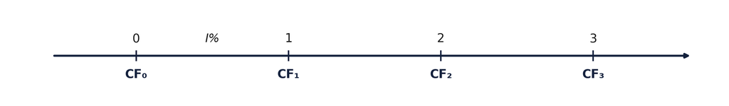

## Saving

You are saving 500 dollars every year starting today and invest in a fund that earns 7% yearly. How much should you expect to have at the end of 3 years?

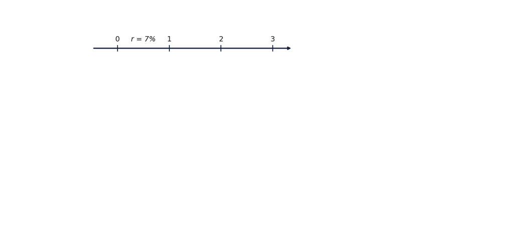

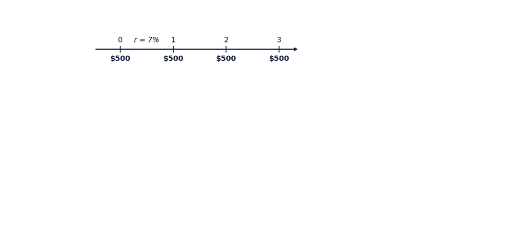

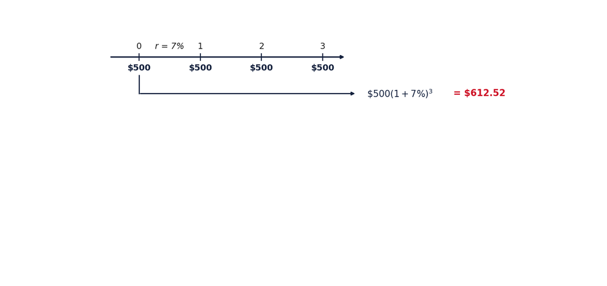

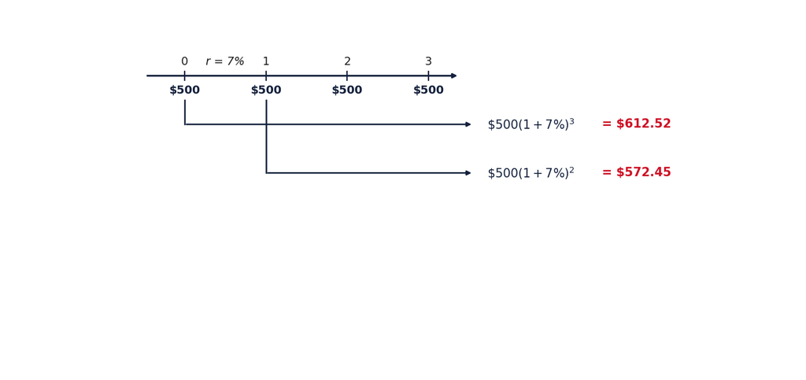

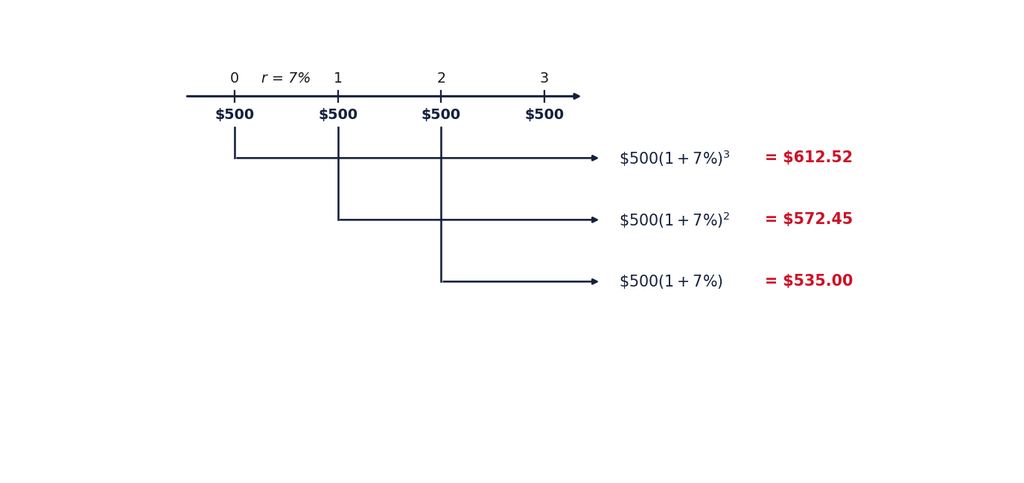

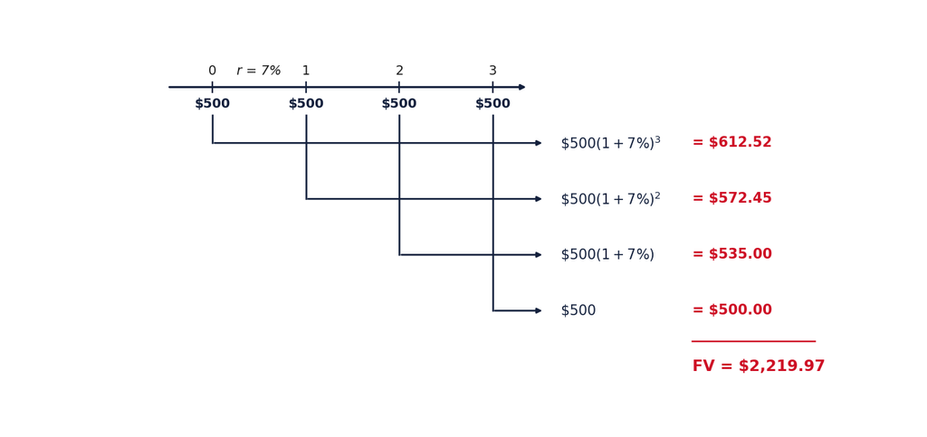

## Investing

You invest $5k today and $1,200 dollars every year for the next three years in a savings account that earns 3%. How much should you expect to have at the end of 3 years?

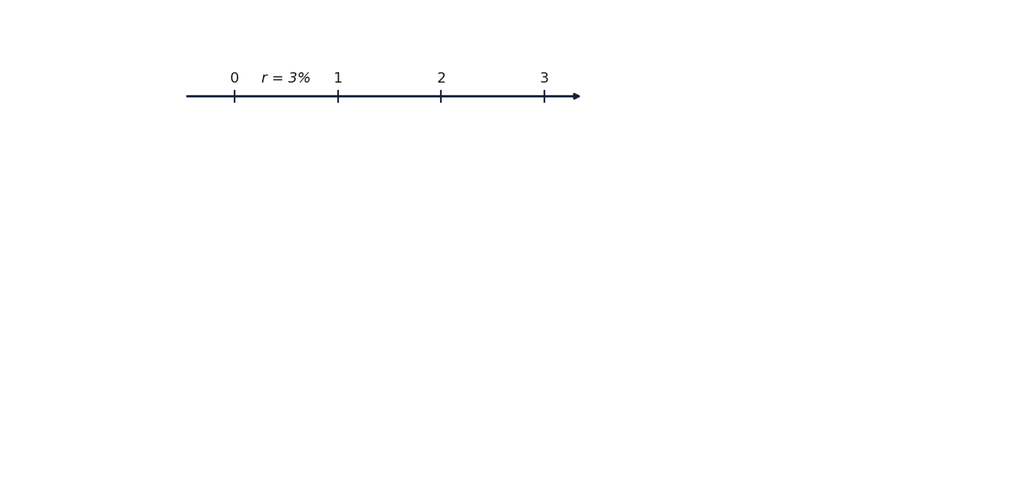

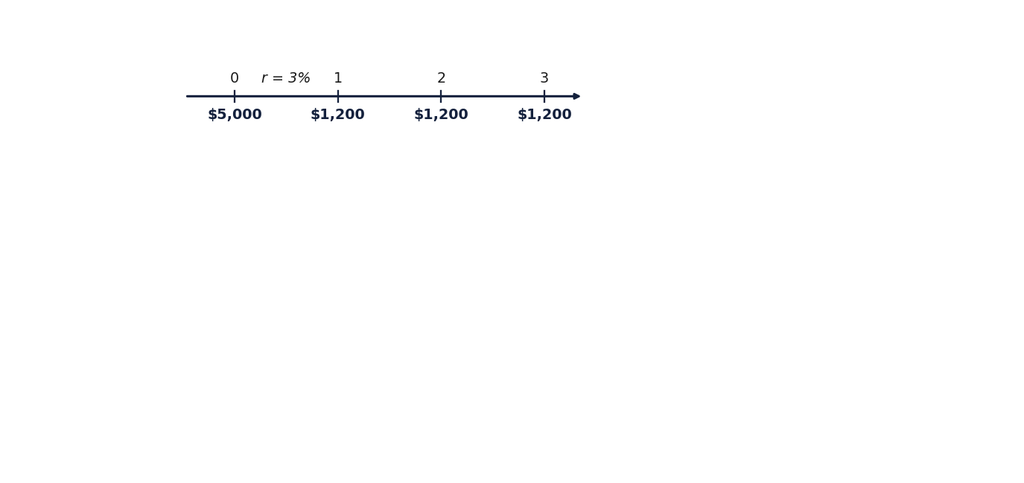

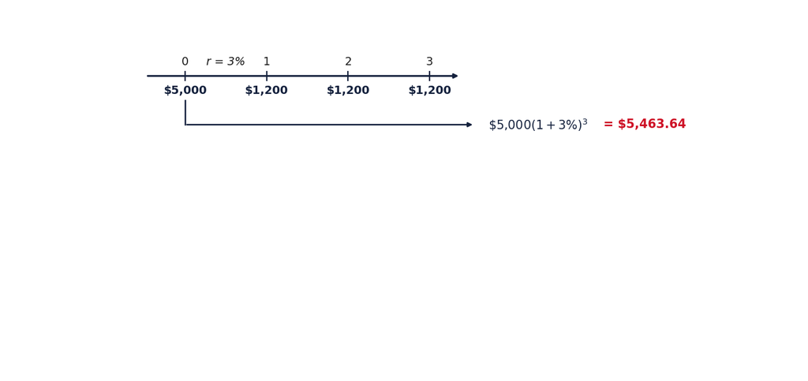

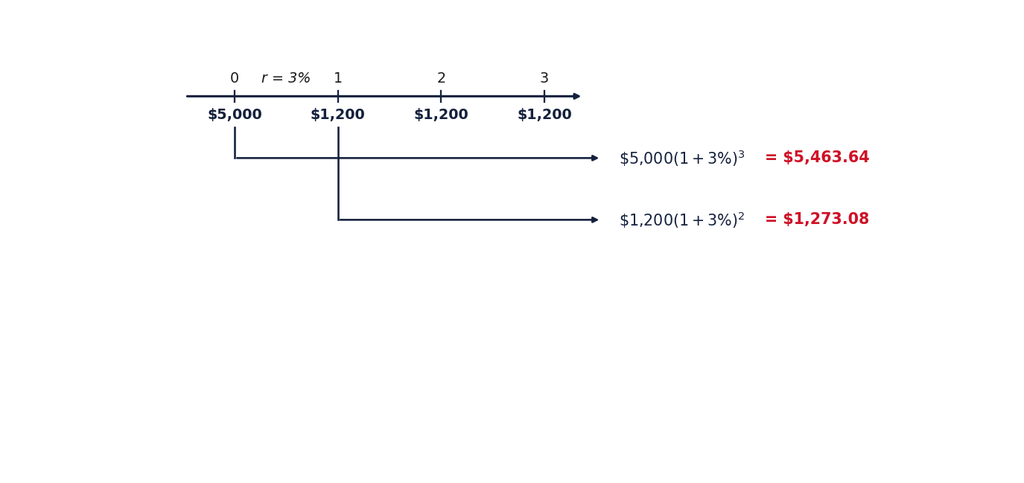

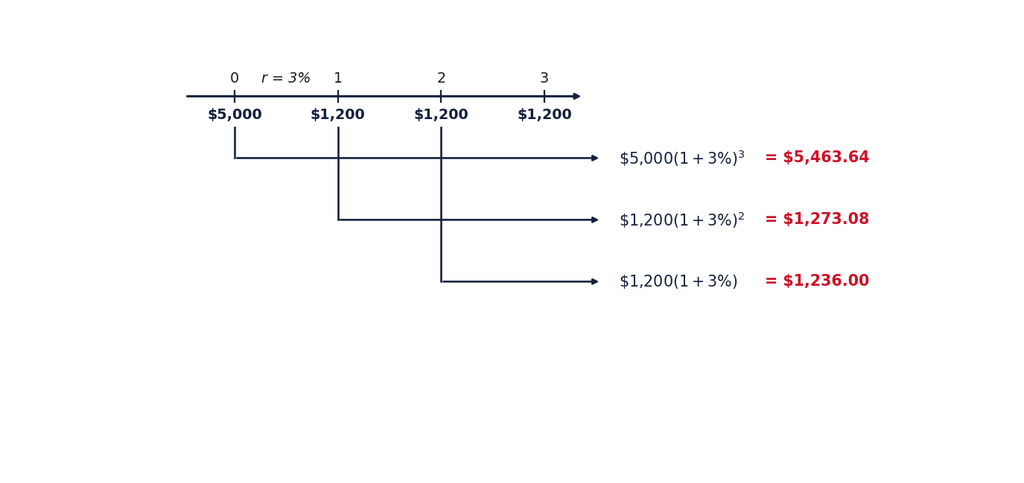

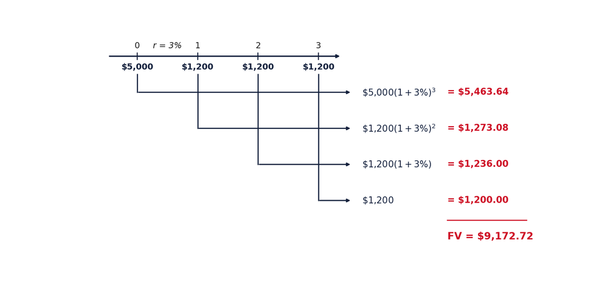

## Compound Interest

You save $10,000 at the end of every year for 5 years. The account earns 12%.

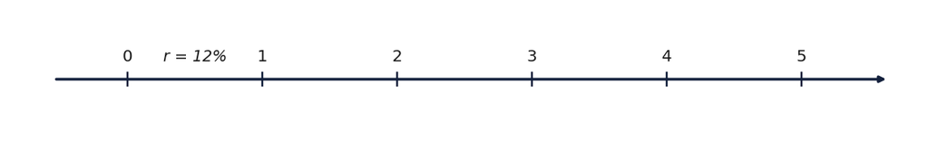

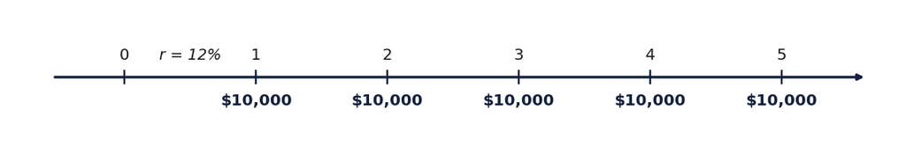

Balance in the account at the end of each year at 12%, with the deposits and the interest accumulated to date

| Year | Beginning balance | Interest earned | Deposit | Ending balance | Cumulative principal | Cumulative interest |
| --- | --- | --- | --- | --- | --- | --- |
| 1 | $0.00 | $0.00 | $10,000.00 | $10,000.00 | $10,000.00 | $0.00 |
| 2 | $10,000.00 | $1,200.00 | $10,000.00 | $21,200.00 | $20,000.00 | $1,200.00 |
| 3 | $21,200.00 | $2,544.00 | $10,000.00 | $33,744.00 | $30,000.00 | $3,744.00 |
| 4 | $33,744.00 | $4,049.28 | $10,000.00 | $47,793.28 | $40,000.00 | $7,793.28 |
| 5 | $47,793.28 | $5,735.19 | $10,000.00 | $63,528.47 | $50,000.00 | $13,528.47 |
| Total |  | $13,528.47 | $50,000.00 | $63,528.47 |  |  |

## Out to 20 years

The same $10,000 a year at 12%, carried out to 20 years.

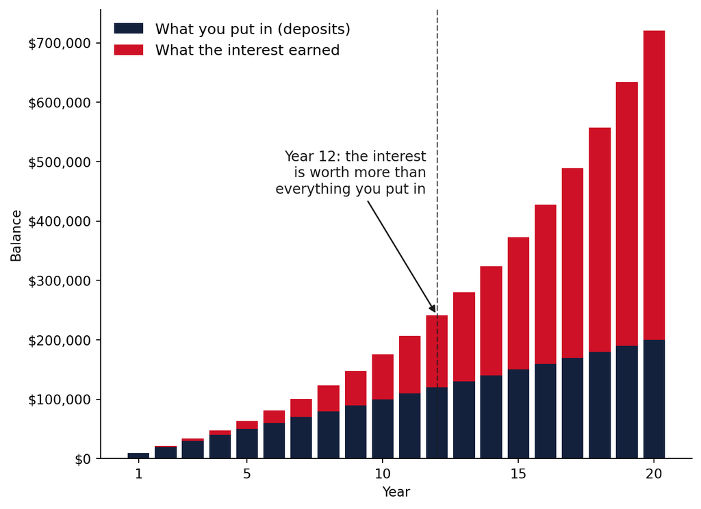

Deposits made and interest earned to date, at the end of each year

| Year | Principal | Interest |
| --- | --- | --- |
| 1 | $10,000 | $0 |
| 2 | $20,000 | $1,200 |
| 3 | $30,000 | $3,744 |
| 4 | $40,000 | $7,793 |
| 5 | $50,000 | $13,528 |
| 6 | $60,000 | $21,152 |
| 7 | $70,000 | $30,890 |
| 8 | $80,000 | $42,997 |
| 9 | $90,000 | $57,757 |
| 10 | $100,000 | $75,487 |
| 11 | $110,000 | $96,546 |
| 12 | $120,000 | $121,331 |
| 13 | $130,000 | $150,291 |
| 14 | $140,000 | $183,926 |
| 15 | $150,000 | $222,797 |
| 16 | $160,000 | $267,533 |
| 17 | $170,000 | $318,837 |
| 18 | $180,000 | $377,497 |
| 19 | $190,000 | $444,397 |
| 20 | $200,000 | $520,524 |

## PV

- Present value is the value of CFs in the future today
- Recall

$$\begin{array}{rlll}
FV_{N} = & PV\left(1+I\right)^{N} \\
\frac{FV_{N}}{\left(1+I\right)^{N}} = & PV
\end{array}$$

## Money today

How much do you need to invest today to have 100 dollars in 2 years? The rate is 6%

$$PV=\frac{FV_{2}}{\left(1+I\right)^{2}}=\frac{\$100}{\left(1+6\%\right)^{2}}=\$89$$

## Money today

How much do you need to invest today to have 100 dollars in 2 years?

Assume that we invested $x$ at 6%.

$$x$$

$$x\left(1+6\%\right)$$

$$x\left(1+6\%\right)^{2}=\$100$$

Rearranging:

$$x=\frac{\$100}{\left(1+6\%\right)^{2}}=PV$$

$$x=\$89$$

## PV

How much do you need to invest today to have $5K three years from today if the discount rate is 5%?

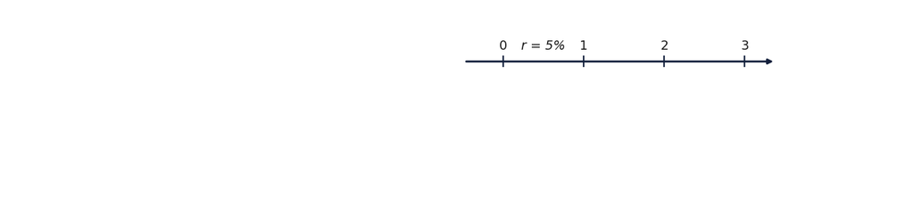

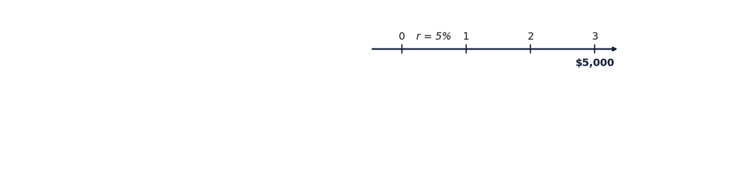

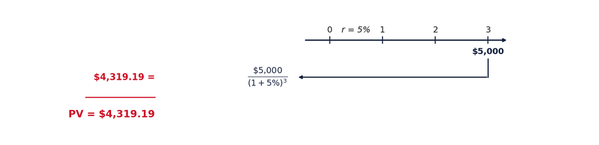

## How to get paid?

You have agreed to work for Justin’s Cupcakes for the summer, 3 months. I offer to pay you 6K at the end of the summer or $1.8K at the end of every month. The rate is 3%. Which do you prefer? (Find the PV of each option.)

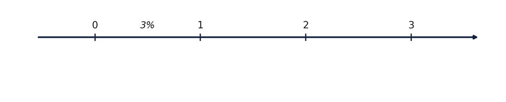

## How to get paid?

You have agreed to work for Justin’s Cupcakes for the summer, 3 months. I offer to pay you 6K at the end of the summer or $1.8K at the end of every month. The rate is 3%. Which do you prefer? (Find the PV of each option.)

Option 1

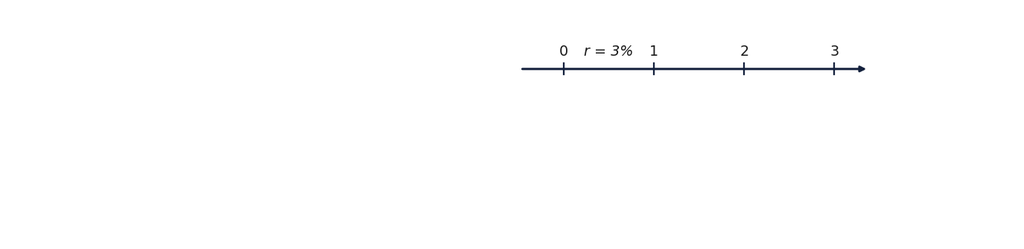

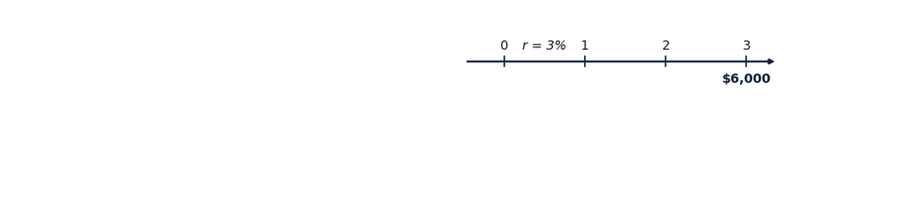

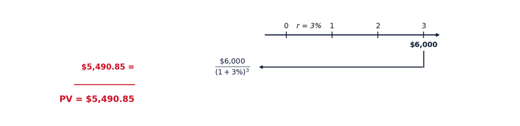

## How to get paid?

You have agreed to work for Justin’s Cupcakes for the summer, 3 months. I offer to pay you 6K at the end of the summer or $1.8K at the end of every month. The rate is 3%. Which do you prefer? (Find the PV of each option.)

Option 2

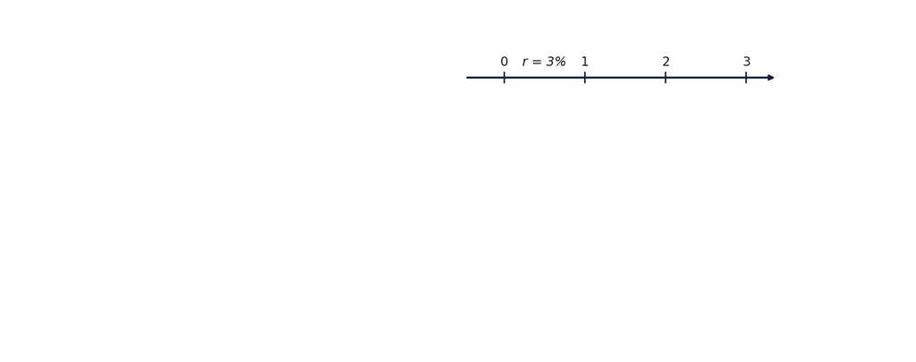

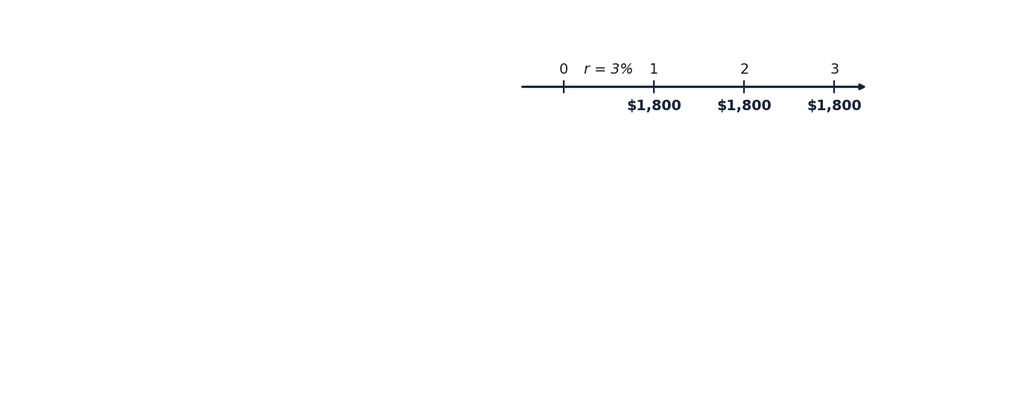

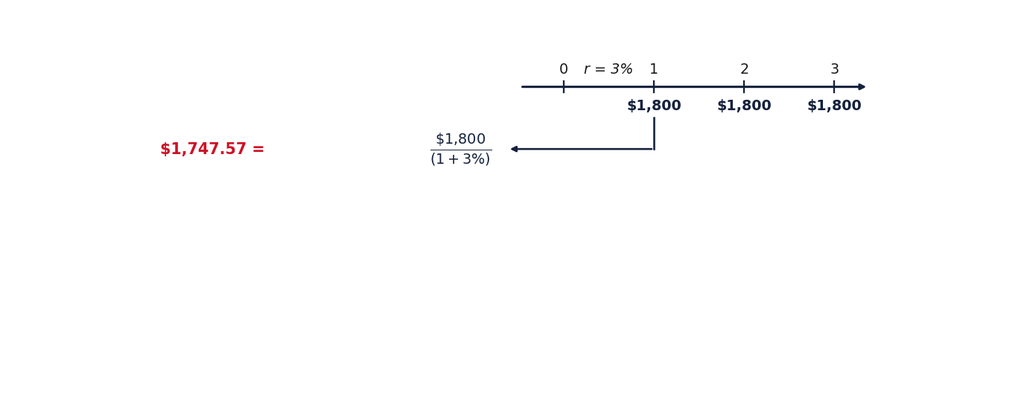

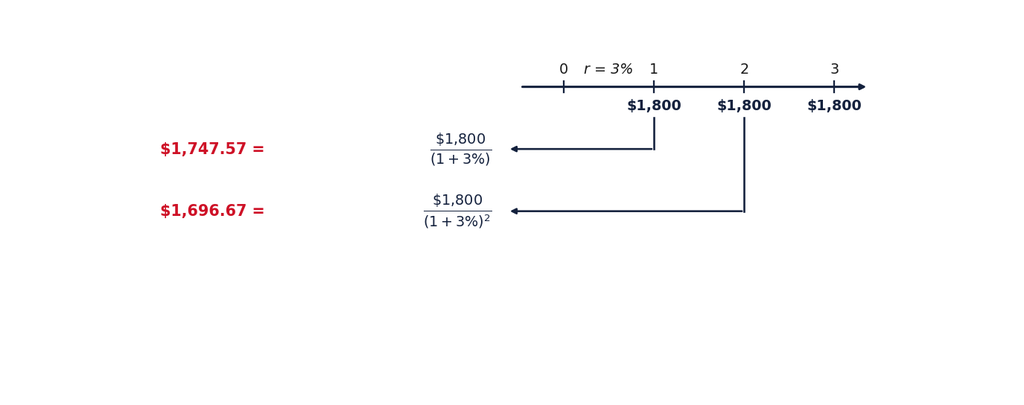

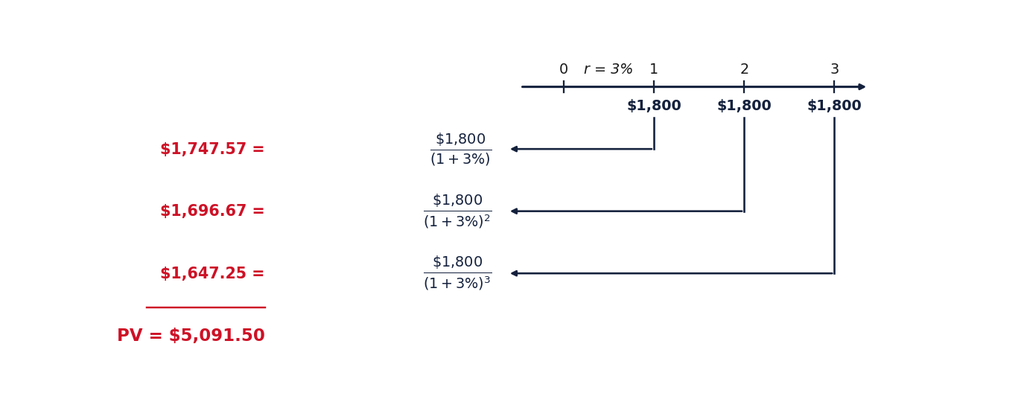